# Project: Identify Customer Segments

> This is a Udacity Unsupervised Learning Project using Real Demographic & Customer Data

##### Context

In this project, I used unsupervised learning techniques to identify segments of the population that form the core customer base for a mail-order sales company in Germany. These segments can then be used to direct marketing campaigns towards audiences that will have the highest expected rate of returns. The data that was used was provided by Udacity's partners at Bertelsmann Arvato Analytics.

##### Importing Libraries

```python
import numpy as np
import pandas as pd
from scipy.stats import ks_2samp
import time

import matplotlib.pyplot as plt
import seaborn as sns
import plotly_express as px
%matplotlib inline

from sklearn.preprocessing import OneHotEncoder,StandardScaler
from sklearn.impute import SimpleImputer
from sklearn.decomposition import PCA
from sklearn.cluster import KMeans
```

## Loading the Data

We will examine, explore, clean, and cluster the Germany demographics data `Udacity_AZDIAS_Subset.csv`, then apply all the same transformations & cleaning to the customer demographics data `Udacity_CUSTOMERS_Subset.csv`. Each row represents a singple person, and includes information outside of individuals, including information about their household, building, and neighborhood. I will use this information to cluster the general population into groups with similar demographic properties. Then, I will see how the people in the customers dataset fit into those created clusters.

After, we will compare the clusters between the general Germany demographic data with the customer data to see whether there are any over-represented clusters in our customer data. This cluster can be interpretted as the company's *core user base*, and could be targetted for future marketing campaigns. Alternatively, under-represented clusters may be viewed as a potential opportunity of expansion for the mail order company.

*Let's Begin*...

Loading in our general demographics data & feature summary file...

```python
# Setting display to show all rows
    # Apologies in advance for cluttering the notebook, but this makes for more convenient analysis
pd.options.display.max_rows = 260
```

```python
# Load in the general demographics data.
azdias = pd.read_csv('Udacity_AZDIAS_Subset.csv',';')

# Load in the feature summary file.
    # Feature summary file contains very useful information about the data types for each feature
feat_info = pd.read_csv('AZDIAS_Feature_Summary.csv',';')
```

Taking a look at our general demographics...

```python
azdias.shape
```

```
(891221, 85)
```

```python
azdias.head()
```

|  | AGER_TYP | ALTERSKATEGORIE_GROB | ANREDE_KZ | CJT_GESAMTTYP | FINANZ_MINIMALIST | FINANZ_SPARER | FINANZ_VORSORGER | FINANZ_ANLEGER | FINANZ_UNAUFFAELLIGER | FINANZ_HAUSBAUER | ... | PLZ8_ANTG1 | PLZ8_ANTG2 | PLZ8_ANTG3 | PLZ8_ANTG4 | PLZ8_BAUMAX | PLZ8_HHZ | PLZ8_GBZ | ARBEIT | ORTSGR_KLS9 | RELAT_AB |
| --- | --- | --- | --- | --- | --- | --- | --- | --- | --- | --- | --- | --- | --- | --- | --- | --- | --- | --- | --- | --- | --- |
| 0 | -1 | 2 | 1 | 2.0 | 3 | 4 | 3 | 5 | 5 | 3 | ... | NaN | NaN | NaN | NaN | NaN | NaN | NaN | NaN | NaN | NaN |
| 1 | -1 | 1 | 2 | 5.0 | 1 | 5 | 2 | 5 | 4 | 5 | ... | 2.0 | 3.0 | 2.0 | 1.0 | 1.0 | 5.0 | 4.0 | 3.0 | 5.0 | 4.0 |
| 2 | -1 | 3 | 2 | 3.0 | 1 | 4 | 1 | 2 | 3 | 5 | ... | 3.0 | 3.0 | 1.0 | 0.0 | 1.0 | 4.0 | 4.0 | 3.0 | 5.0 | 2.0 |
| 3 | 2 | 4 | 2 | 2.0 | 4 | 2 | 5 | 2 | 1 | 2 | ... | 2.0 | 2.0 | 2.0 | 0.0 | 1.0 | 3.0 | 4.0 | 2.0 | 3.0 | 3.0 |
| 4 | -1 | 3 | 1 | 5.0 | 4 | 3 | 4 | 1 | 3 | 2 | ... | 2.0 | 4.0 | 2.0 | 1.0 | 2.0 | 3.0 | 3.0 | 4.0 | 6.0 | 5.0 |

5 rows × 85 columns

Skimming the numerical data summary statistics...

```python
azdias.describe().transpose()
```

|  | count | mean | std | min | 25% | 50% | 75% | max |
| --- | --- | --- | --- | --- | --- | --- | --- | --- |
| AGER_TYP | 891221.0 | -0.358435 | 1.198724 | -1.0 | -1.0 | -1.0 | -1.0 | 3.0 |
| ALTERSKATEGORIE_GROB | 891221.0 | 2.777398 | 1.068775 | 1.0 | 2.0 | 3.0 | 4.0 | 9.0 |
| ANREDE_KZ | 891221.0 | 1.522098 | 0.499512 | 1.0 | 1.0 | 2.0 | 2.0 | 2.0 |
| CJT_GESAMTTYP | 886367.0 | 3.632838 | 1.595021 | 1.0 | 2.0 | 4.0 | 5.0 | 6.0 |
| FINANZ_MINIMALIST | 891221.0 | 3.074528 | 1.321055 | 1.0 | 2.0 | 3.0 | 4.0 | 5.0 |
| FINANZ_SPARER | 891221.0 | 2.821039 | 1.464749 | 1.0 | 1.0 | 3.0 | 4.0 | 5.0 |
| FINANZ_VORSORGER | 891221.0 | 3.401106 | 1.322134 | 1.0 | 3.0 | 3.0 | 5.0 | 5.0 |
| FINANZ_ANLEGER | 891221.0 | 3.033328 | 1.529603 | 1.0 | 2.0 | 3.0 | 5.0 | 5.0 |
| FINANZ_UNAUFFAELLIGER | 891221.0 | 2.874167 | 1.486731 | 1.0 | 2.0 | 3.0 | 4.0 | 5.0 |
| FINANZ_HAUSBAUER | 891221.0 | 3.075121 | 1.353248 | 1.0 | 2.0 | 3.0 | 4.0 | 5.0 |
| FINANZTYP | 891221.0 | 3.790586 | 1.987876 | 1.0 | 2.0 | 4.0 | 6.0 | 6.0 |
| GEBURTSJAHR | 891221.0 | 1101.178533 | 976.583551 | 0.0 | 0.0 | 1943.0 | 1970.0 | 2017.0 |
| GFK_URLAUBERTYP | 886367.0 | 7.350304 | 3.525723 | 1.0 | 5.0 | 8.0 | 10.0 | 12.0 |
| GREEN_AVANTGARDE | 891221.0 | 0.196612 | 0.397437 | 0.0 | 0.0 | 0.0 | 0.0 | 1.0 |
| HEALTH_TYP | 891221.0 | 1.792102 | 1.269062 | -1.0 | 1.0 | 2.0 | 3.0 | 3.0 |
| LP_LEBENSPHASE_FEIN | 886367.0 | 14.622637 | 12.616883 | 0.0 | 4.0 | 11.0 | 27.0 | 40.0 |
| LP_LEBENSPHASE_GROB | 886367.0 | 4.453621 | 3.855639 | 0.0 | 1.0 | 3.0 | 8.0 | 12.0 |
| LP_FAMILIE_FEIN | 886367.0 | 3.599574 | 3.926486 | 0.0 | 1.0 | 1.0 | 8.0 | 11.0 |
| LP_FAMILIE_GROB | 886367.0 | 2.185966 | 1.756537 | 0.0 | 1.0 | 1.0 | 4.0 | 5.0 |
| LP_STATUS_FEIN | 886367.0 | 4.791151 | 3.425305 | 1.0 | 2.0 | 4.0 | 9.0 | 10.0 |
| LP_STATUS_GROB | 886367.0 | 2.432575 | 1.474315 | 1.0 | 1.0 | 2.0 | 4.0 | 5.0 |
| NATIONALITAET_KZ | 891221.0 | 1.026827 | 0.586634 | 0.0 | 1.0 | 1.0 | 1.0 | 3.0 |
| PRAEGENDE_JUGENDJAHRE | 891221.0 | 8.154346 | 4.844532 | 0.0 | 5.0 | 8.0 | 14.0 | 15.0 |
| RETOURTYP_BK_S | 886367.0 | 3.419630 | 1.417741 | 1.0 | 2.0 | 3.0 | 5.0 | 5.0 |
| SEMIO_SOZ | 891221.0 | 3.945860 | 1.946564 | 1.0 | 2.0 | 4.0 | 6.0 | 7.0 |
| SEMIO_FAM | 891221.0 | 4.272729 | 1.915885 | 1.0 | 3.0 | 4.0 | 6.0 | 7.0 |
| SEMIO_REL | 891221.0 | 4.240609 | 2.007373 | 1.0 | 3.0 | 4.0 | 6.0 | 7.0 |
| SEMIO_MAT | 891221.0 | 4.001597 | 1.857540 | 1.0 | 2.0 | 4.0 | 5.0 | 7.0 |
| SEMIO_VERT | 891221.0 | 4.023709 | 2.077746 | 1.0 | 2.0 | 4.0 | 6.0 | 7.0 |
| SEMIO_LUST | 891221.0 | 4.359086 | 2.022829 | 1.0 | 2.0 | 5.0 | 6.0 | 7.0 |

[output cut: 51 more lines]

Now taking a look at our feature summary file `AZDIAS_Feature_Summary.csv`...

```python
feat_info.shape
```

```
(85, 4)
```

```python
# As you can see, we have convenient information on type of data and a code telling us what values denote NA values
feat_info.head()
```

|  | attribute | information_level | type | missing_or_unknown |
| --- | --- | --- | --- | --- |
| 0 | AGER_TYP | person | categorical | [-1,0] |
| 1 | ALTERSKATEGORIE_GROB | person | ordinal | [-1,0,9] |
| 2 | ANREDE_KZ | person | categorical | [-1,0] |
| 3 | CJT_GESAMTTYP | person | categorical | [0] |
| 4 | FINANZ_MINIMALIST | person | ordinal | [-1] |

## Preprocessing

### Assessing Missing Data

**Converting Missing Value Codes to NaNs**

The fourth column of the feature attributes summary (loaded in above as `feat_info`) tells us what codes indicate missing/NA values (e.g. [-1,0]). However, we have to convert these codes as a list because it's encoded as a string of a list.

> When converting a DataFrame to csv, any columns containing Python `list` datatypes are converted to strings.

So, before we encode our NA values using the feature summary `missing_or_unknown` column, we need to first convert this column into a list.

Just for fun, let's see how many NA values are already recognized by Pandas.

```python
# Total number of known missing values (Pandas recognizes as NA)
    # the first .sum() is used to sum across all columns. The second .sum() is used to aggregate all NAs
azdias.isna().sum().sum()
```

```
4896838
```

```python
# Using this function to convert the strings of a list to actual lists
def string_to_list(x):
    '''
    This function takes a string of a list and returns a list containing integers and strings.
    Note the list can only contain alphanumeric values for it to work.

    Input: String of a list (i.e. '[1,2,XX]')
    Returns: List data type
    '''
    new_list=[]
    # The below line removes the '[]' and splits on ',', creating a list of strings
    x = x[1:-1].split(',')
    # For each value in the list of strings, try turning it into an integer if possible and append to new_list
        # Otherwise, append it to new_list
    for i in x:
        try:
            new_list.append(int(i))
        except:
            new_list.append(i)
    return new_list
```

```python
# Applying the function
feat_info['NA_tags'] = feat_info['missing_or_unknown'].apply(string_to_list)
```

```python
# Example of an entry in this new column
type(feat_info['NA_tags'][0])
```

```
list
```

As you can see, we've successfully converted these entries into Python lists

```python
feat_info.head()
```

|  | attribute | information_level | type | missing_or_unknown | NA_tags |
| --- | --- | --- | --- | --- | --- |
| 0 | AGER_TYP | person | categorical | [-1,0] | [-1, 0] |
| 1 | ALTERSKATEGORIE_GROB | person | ordinal | [-1,0,9] | [-1, 0, 9] |
| 2 | ANREDE_KZ | person | categorical | [-1,0] | [-1, 0] |
| 3 | CJT_GESAMTTYP | person | categorical | [0] | [0] |
| 4 | FINANZ_MINIMALIST | person | ordinal | [-1] | [-1] |

Now that that's out of the way, let's encode our NA values.

Inserting NA values into our DataFrame if they are tagged as NA in the "NA_tags" column

```python
# Using a nearly identical copy of the feat_info DF with the attributes as the index
att_index = feat_info.set_index('attribute')
```

```python
# This is an example of what I just created. You'll see what I did this in a moment
att_index.head(1)
```

| attribute | information_level | type | missing_or_unknown | NA_tags |
| --- | --- | --- | --- | --- |
| AGER_TYP | person | categorical | [-1,0] | [-1, 0] |

```python
# Creating a copy of the demographics data to work with to be the version with NA's inserted
na_azdias = azdias[:]
```

Below I'm looking through each column, using the `att_index` DataFrame as a reference to encode our NA values. I needed the *features* to be the *index* of the dataframe in order to use `.loc` to retrieve each column's respective list of NA codes.

```python
# Looping through our column names
for column in na_azdias.columns:
    # For every column in our DF, if a value is in the 'NA_tags' list, we replace it inplace with np.NaN
    na_azdias[column].replace(att_index.loc[column].loc['NA_tags'],np.NaN,inplace=True)
```

```python
# Now we have about 3,500,000 more NA values as a result of this replacement
na_azdias.isna().sum().sum()
```

```
8373929
```

#### Assessing Missing Data in Each Column

Below we will asses how much data is missing in each column and row to understand...

1. How much data should we drop, if any?
2. If we choose to drop some data, what are the implications of doing so?

Below is a simple textual representation of how many NA values are in each column. As you can see, columns starting with `FINANZ...` and `SEMIO...` don't have *any* missing values. This must be standard person-level data, mandatory for each observation.

```python
na_azdias.isna().sum()
```

```
AGER_TYP                 685843
ALTERSKATEGORIE_GROB       2881
ANREDE_KZ                     0
CJT_GESAMTTYP              4854
FINANZ_MINIMALIST             0
FINANZ_SPARER                 0
FINANZ_VORSORGER              0
FINANZ_ANLEGER                0
FINANZ_UNAUFFAELLIGER         0
FINANZ_HAUSBAUER              0
FINANZTYP                     0
GEBURTSJAHR              392318
GFK_URLAUBERTYP            4854
GREEN_AVANTGARDE              0
HEALTH_TYP               111196
LP_LEBENSPHASE_FEIN       97632
LP_LEBENSPHASE_GROB       94572
LP_FAMILIE_FEIN           77792
LP_FAMILIE_GROB           77792
LP_STATUS_FEIN             4854
LP_STATUS_GROB             4854
NATIONALITAET_KZ         108315
PRAEGENDE_JUGENDJAHRE    108164
RETOURTYP_BK_S             4854
SEMIO_SOZ                     0
SEMIO_FAM                     0
SEMIO_REL                     0
SEMIO_MAT                     0
SEMIO_VERT                    0
SEMIO_LUST                    0
SEMIO_ERL                     0
SEMIO_KULT                    0
SEMIO_RAT                     0
SEMIO_KRIT                    0
SEMIO_DOM                     0
SEMIO_KAEM                    0
SEMIO_PFLICHT                 0
SEMIO_TRADV                   0
SHOPPER_TYP              111196
SOHO_KZ                   73499
```

[output cut: 31 more lines]

```
MOBI_REGIO               133324
ONLINE_AFFINITAET          4854
REGIOTYP                 158064
KBA13_ANZAHL_PKW         105800
PLZ8_ANTG1               116515
PLZ8_ANTG2               116515
PLZ8_ANTG3               116515
PLZ8_ANTG4               116515
PLZ8_BAUMAX              116515
PLZ8_HHZ                 116515
PLZ8_GBZ                 116515
ARBEIT                    97375
ORTSGR_KLS9               97274
RELAT_AB                  97375
dtype: int64
```

Below I'm making a temporary DataFrame to help me understand the question: **how much data is missing in each column?**

```python
# Creating a copy of the DF containing the counts of NAs with the names of the columns in the original DF as a column
na_azdias_df = na_azdias.isna().sum().reset_index()
# Filtering for only columns with more than 50000 NA values to declutter the plot
temp_view = na_azdias_df[na_azdias_df[0]>50000]
```

```python
# FYI - 'index' is column name and '0' is count of NA values
temp_view.head(1)
```

|  | index | 0 |
| --- | --- | --- |
| 0 | AGER_TYP | 685843 |

Below is a horizontal bar plot showing columns and their NA counts as their bar width. Here I've noted that the following columns have **much** more NA values than the others...

- KBA05_BAUMAX
- KK_KUNDENTYP
- ALTER_HH
- TITEL_KZ
- GEBURTSJAHR
- AGER_TYP

```python
# Sorting by count of NA values
temp_view.sort_values(by=0,ascending=True,inplace=True)
```

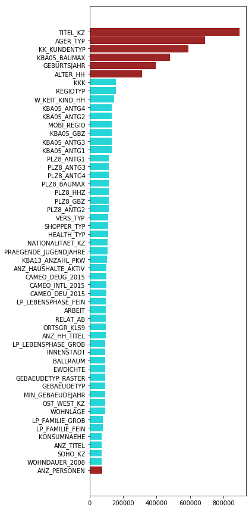

```python
plt.figure(figsize=(6,12))
barh = plt.barh(temp_view['index'],temp_view[0],color = 'darkturquoise', alpha = 0.85)
for i in range(7):
    barh[-i].set_color('darkred')
plt.tight_layout()
```

So now I'll remove those 6 outlier columns...

```python
outlier_columns = ['KBA05_BAUMAX','KK_KUNDENTYP','ALTER_HH','TITEL_KZ','GEBURTSJAHR','AGER_TYP']
```

```python
na_azdias.drop(labels=outlier_columns,axis=1,inplace=True)
```

Printing the shape shows that the no. columns decreased from 85 -> 79

```python
na_azdias.shape
```

```
(891221, 79)
```

**Recap**

I plotted the count of NA values per column and noted that the following 6 columns were outliers in terms of number of missing values, and were subsequently **removed**.

- KBA05_BAUMAX
- KK_KUNDENTYP
- ALTER_HH
- TITEL_KZ
- GEBURTSJAHR
- AGER_TYP

#### Assessing Missing Data in Each Row

Below I will asses how much data is missing in each row, and evaluate whether I should drop any rows.

This analysis is going to be a bit more work that assessing missing data in each column, because dropping rows has more implications than dropping columns. By dropping rows, we're dropping entire observations (one observation being one person), which can skew/misrepresent the demographic data.

Spoiler alert: I will be dropping rows for the sake of compatibility with Principal Component Analysis and KMeans Clustering. Let's understand the consequences of dropping these rows.

```python
# Creating a temp column that contains the count of NA values in each row
na_azdias['no_na_row'] = na_azdias.isna().sum(axis=1)
```

This histogram plots a distribution of non-zero NA values. Looks like most of our rows *with NA values* are missing between 1-10 of their values.

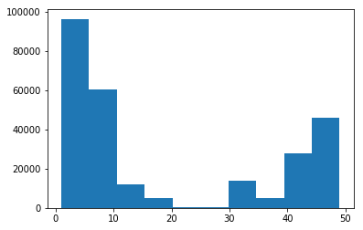

```python
plt.hist(na_azdias[na_azdias['no_na_row']>0]['no_na_row'],bins=10)
```

Because we have a significant number of rows with 30-50 NA values, I'll split the data into two subsets: one with rows with less than or equal to 30 NA values `na_azdias_b30` and one with rows greater than 30 NA values `na_azdias_g30`.

```python
na_azdias_b30 = na_azdias[na_azdias['no_na_row']<=30]
na_azdias_g30 = na_azdias[na_azdias['no_na_row']>30]
```

Below is a quick comparison of the proportion of NA values in each row.

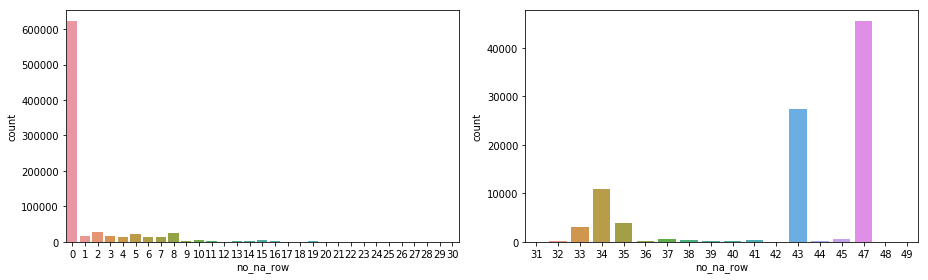

```python
fig,(ax1,ax2) = plt.subplots(1,2,figsize=(13,4))
sns.countplot(x='no_na_row',data=na_azdias_b30,ax=ax1,orient='v')
sns.countplot(x='no_na_row',data=na_azdias_g30,ax=ax2,orient='v')
plt.tight_layout()
```

Now I'll compare the distributions of particular columns' values between the two subsets of data.

Note this is different than what we did in the cell above, which is plot a *distribution* of *rows* for each *number of NA values*.

```python
def compare_columns(df1,df2,column,df1_desc=None,df2_desc=None):
    '''
    Takes two DataFrames and a column name as input and plots two countplots of the given column for both DataFrames.
    '''
    # Taking max value count between the 2 columns to set as ylim for both plots
    df1_max = df1[column].value_counts().iloc[0]
    df2_max = df2[column].value_counts().iloc[0]
    if df1_max > df2_max:
        top = df1_max * 1.05
    else:
        top = df2_max * 1.05

    # Plotting
    fig,(ax1,ax2) = plt.subplots(1,2,figsize=(10,3))
    sns.countplot(df1[column],ax=ax1)
    ax1.set_ylabel('Count')
    ax1.set_ylim(top=top)
    ax1.set_title(df1_desc)
    sns.countplot(df2[column],ax=ax2)
    ax2.set_ylabel('Count')
    ax2.set_ylim(top=top)
    ax2.set_title(df2_desc)
    plt.tight_layout()
```

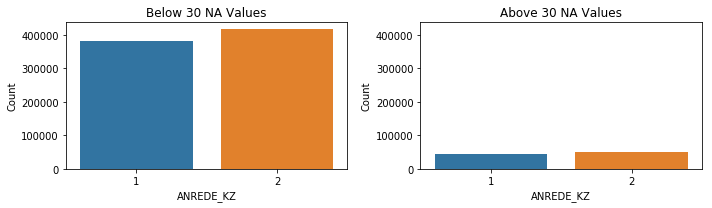

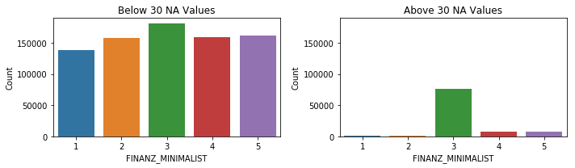

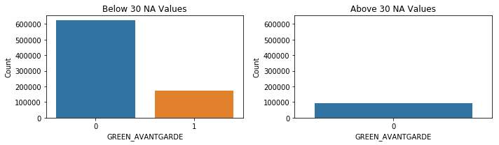

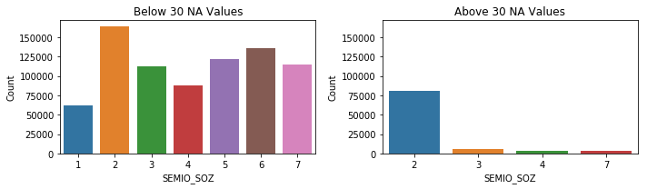

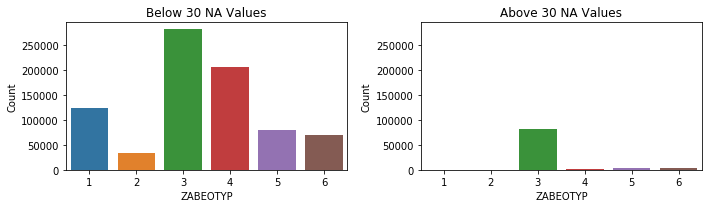

```python
for n in ['ANREDE_KZ','FINANZ_MINIMALIST','GREEN_AVANTGARDE','SEMIO_SOZ','ZABEOTYP']:
    compare_columns(na_azdias_b30,na_azdias_g30,n,"Below 30 NA Values","Above 30 NA Values")
```

Clearly, the subset of data with more than 30 NA values in each row (plots on the right) is much **smaller** than the other subset. Additionally, the **distribution** of values between the two subsets of data are **different** for all of the columns above wish the exception of column "ANREDE_KZ" (Gender).

> Note that we're looking at columns with *zero* NA values and comparing rows with many NA values against rows with little NA values.

This suggests a possible bias introduced in the way the data was collected and/or entered. Whatever the case may be, these rows with many NA values should be investigated, since they should *hypothetically* be similarly distributed relative to the other subset of data with less than 30 NA values.

Additional supplementary visualization. Plots Distribution plots for first 10 columns on top of one another.

**This does't add much more information. Feel free to skim over this viz.**

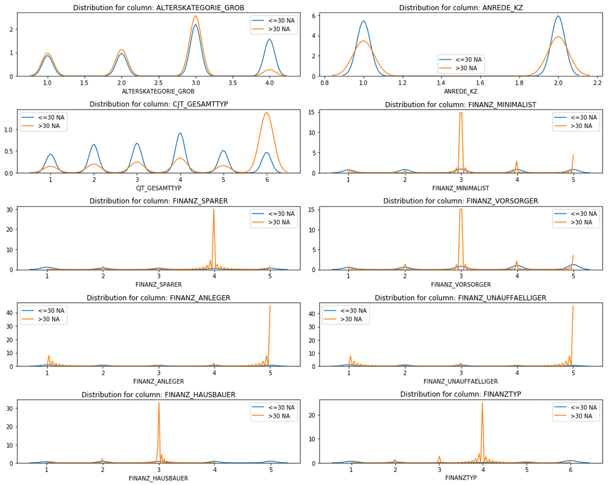

```python
plt.figure(figsize=(15,12))
for i, col in enumerate(na_azdias_b30.columns[:10]):
    plt.subplot(5, 2, i+1)
    sns.distplot(na_azdias_b30[col][na_azdias_b30[col].notnull()], label='<=30 NA',hist=False)
    sns.distplot(na_azdias_g30[col][na_azdias_g30[col].notnull()], label='>30 NA',hist=False)
    plt.title('Distribution for column: {}'.format(col))
    plt.legend();

plt.tight_layout()
plt.show()
```

##### Kolmogorov-Smirnov Test

Below I'll use the KS test to compare *each column's distributions* from our two datasets (rows with <30 NA values & rows with >30 NA values).

**Purpose:** To evaluate how different these two groups of data are distributed. *If we see that these distributions are very different* (low p-values as a result of our KS-Test), then we have *statistical evidence that we can use to evaluate whether we should drop* the >30 NA values-per row subset.

TL;DR? Scroll down below for my interpretation of the KS test and a quick note on how it works.

```python
def KS_col_test(df1,df2):
    '''
    Used to evaluate whether distributions of data between two DataFrames with the same columns are different.

    Input: 2 DataFrames with identical columns.
    Output: D (KS Stat | Max Distance between the two cumulative probability functions for each Dataset) and p-values associated to each D
    '''
    # Lists for the KS Stat (D) and p-values to return
    stats = []
    p_values = []

    # Grabbing an array of column names
    cols = df1.columns.values

    for col in cols:
        try:
            D,p = ks_2samp(df1[col],df2[col])
            stats.append(D)
            p_values.append(p)
        except:
            stats.append(np.NaN)
            p_values.append(np.NaN)

    return stats,p_values
```

```python
# Calculating stats and p-values for each column
stats,p_values = KS_col_test(na_azdias_b30,na_azdias_g30)
```

```python
# Creating a DataFrame to store the results. 80 rows (1/feature)
ks_df = pd.DataFrame(na_azdias_b30.columns.values,columns=['feature'])
ks_df['stat'] = stats
ks_df['p_value'] = p_values
```

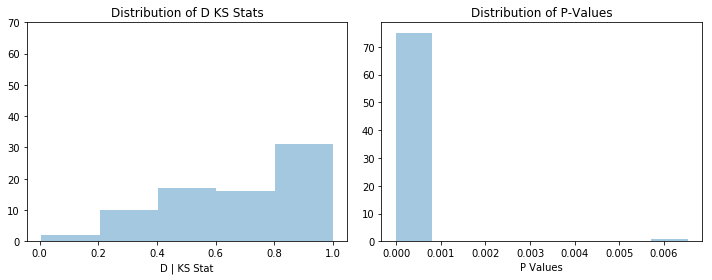

```python
# Plotting results. See below for my interpretation
fig,(ax1,ax2) = plt.subplots(1,2,figsize=(10,4))

sns.distplot(ks_df[ks_df['stat'].notnull()]['stat'],ax=ax1,kde=False)
ax1.set_title('Distribution of D KS Stats')
ax1.set_xlabel('D | KS Stat')
ax1.set_ylim(top=70)

sns.distplot(ks_df[ks_df['p_value'].notnull()]['p_value'],ax=ax2,kde=False)
ax2.set_title('Distribution of P-Values')
ax2.set_xlabel('P Values')

plt.tight_layout()
plt.show()
```

So let's recap what we just did. We have two DataFrames:

1. `na_azdiasb30` DataFrame with <= 30 NA values per row
2. `na_azdiasg30` DataFrame with > 30 NA values per row

We used SciPy's implementation of the 2-way Kolmogorov-Smirnov test on *each of the 80 columns* to evaluate the similarity of each column's distributions.

*Brief Aside on the KS-Test*

The KS test measures similarity *between two samples* to check whether these two samples *came from the same distribution*. (In our case, we're checking if the values in each of our DataFrames for each column are distributed similarly to evaluate the consequence of us dropping one of these DataFrames; namely, the DataFrame with more NA values). The KS test creates empirical **cumulative distribution functions** (one for each sample/group of observations) and compares them. We take the difference of these two distributions, and the *maximum difference (D)* is our D/KS Stat. Then, we measure the p-value (Null Hypothesis: these two samples came from the same disttribution). **If our p-value is low, then we are more confident that the samples come from different distributions**.

**KS Test Conclusion**

So we see that our p-values are *extremely low*, telling us that our distributions between the two DataFrames (30 or less vals and greater than 30 NA vals) are **highly likely to come from different distributions**. I interpret this as a **warning** that if we drop our `na_azdias_g30` DataFrame, we're going to lose valuable information that could affect our algorithm.

##### Consecutive NA Values

Below I investigated the remaining columns containing NA values and found that many of the rows containing NA values have *consecutive* NA values in related columns, such as columns that begin with "KBA05..." and "PLZ8...", suggesting that these missing values are likely not due to the *chance* of random erroneous data entry, and are rather caused by some external factor, such as the process/methodology of how the data was collected.

**TL;DR? Key Finding**: It looks like most rows I got back have many NA values in the same row. For example, the cell immediately below returns rows with NA values in column 'KBA05*ANTG3', and by scrolling right to the end of the DataFrame, we see that the columns that start with 'PLZ8__*' have many rows that have consecutive NA values.

```python
na_azdias[pd.isna(na_azdias['KBA05_ANTG3'])]
```

|  | ALTERSKATEGORIE_GROB | ANREDE_KZ | CJT_GESAMTTYP | FINANZ_MINIMALIST | FINANZ_SPARER | FINANZ_VORSORGER | FINANZ_ANLEGER | FINANZ_UNAUFFAELLIGER | FINANZ_HAUSBAUER | FINANZTYP | ... | PLZ8_ANTG2 | PLZ8_ANTG3 | PLZ8_ANTG4 | PLZ8_BAUMAX | PLZ8_HHZ | PLZ8_GBZ | ARBEIT | ORTSGR_KLS9 | RELAT_AB | no_na_row |
| --- | --- | --- | --- | --- | --- | --- | --- | --- | --- | --- | --- | --- | --- | --- | --- | --- | --- | --- | --- | --- | --- |
| 0 | 2.0 | 1 | 2.0 | 3 | 4 | 3 | 5 | 5 | 3 | 4 | ... | NaN | NaN | NaN | NaN | NaN | NaN | NaN | NaN | NaN | 43 |
| 11 | 2.0 | 1 | 6.0 | 3 | 4 | 3 | 5 | 5 | 3 | 4 | ... | NaN | NaN | NaN | NaN | NaN | NaN | NaN | NaN | NaN | 47 |
| 12 | 3.0 | 1 | 6.0 | 5 | 3 | 4 | 2 | 4 | 1 | 3 | ... | 3.0 | 1.0 | 0.0 | 1.0 | 5.0 | 5.0 | 3.0 | 6.0 | 4.0 | 6 |
| 13 | 1.0 | 2 | 5.0 | 1 | 4 | 3 | 5 | 5 | 2 | 1 | ... | 1.0 | 1.0 | 1.0 | 1.0 | 3.0 | 3.0 | 3.0 | 6.0 | 4.0 | 8 |
| 14 | 3.0 | 1 | 6.0 | 3 | 4 | 3 | 5 | 5 | 3 | 4 | ... | NaN | NaN | NaN | NaN | NaN | NaN | NaN | NaN | NaN | 47 |
| 17 | 2.0 | 1 | 6.0 | 3 | 4 | 3 | 5 | 5 | 3 | 4 | ... | NaN | NaN | NaN | NaN | NaN | NaN | NaN | NaN | NaN | 47 |
| 24 | 3.0 | 2 | 6.0 | 3 | 4 | 3 | 5 | 5 | 3 | 4 | ... | NaN | NaN | NaN | NaN | NaN | NaN | NaN | NaN | NaN | 47 |
| 26 | 3.0 | 1 | 3.0 | 5 | 2 | 4 | 2 | 3 | 1 | 3 | ... | NaN | NaN | NaN | NaN | NaN | NaN | 4.0 | 3.0 | 5.0 | 19 |
| 30 | 3.0 | 2 | 3.0 | 4 | 3 | 4 | 4 | 4 | 1 | 3 | ... | NaN | NaN | NaN | NaN | NaN | NaN | NaN | NaN | NaN | 34 |
| 35 | 2.0 | 2 | 2.0 | 3 | 4 | 3 | 5 | 5 | 3 | 4 | ... | NaN | NaN | NaN | NaN | NaN | NaN | NaN | NaN | NaN | 43 |
| 46 | NaN | 2 | 3.0 | 2 | 4 | 3 | 5 | 5 | 4 | 1 | ... | NaN | NaN | NaN | NaN | NaN | NaN | NaN | NaN | NaN | 40 |
| 48 | 3.0 | 2 | 6.0 | 3 | 4 | 3 | 5 | 5 | 3 | 4 | ... | NaN | NaN | NaN | NaN | NaN | NaN | NaN | NaN | NaN | 47 |
| 53 | 2.0 | 1 | 3.0 | 3 | 4 | 3 | 5 | 5 | 3 | 4 | ... | NaN | NaN | NaN | NaN | NaN | NaN | NaN | NaN | NaN | 43 |
| 54 | 3.0 | 1 | 6.0 | 3 | 4 | 3 | 5 | 5 | 3 | 4 | ... | NaN | NaN | NaN | NaN | NaN | NaN | NaN | NaN | NaN | 47 |
| 61 | 3.0 | 2 | 6.0 | 3 | 4 | 3 | 5 | 5 | 3 | 4 | ... | NaN | NaN | NaN | NaN | NaN | NaN | NaN | NaN | NaN | 43 |
| 62 | 3.0 | 1 | 4.0 | 3 | 4 | 3 | 5 | 5 | 3 | 4 | ... | NaN | NaN | NaN | NaN | NaN | NaN | NaN | NaN | NaN | 43 |
| 69 | 3.0 | 2 | 6.0 | 3 | 4 | 3 | 5 | 5 | 3 | 4 | ... | NaN | NaN | NaN | NaN | NaN | NaN | NaN | NaN | NaN | 47 |
| 75 | 3.0 | 2 | 6.0 | 3 | 4 | 3 | 5 | 5 | 3 | 4 | ... | NaN | NaN | NaN | NaN | NaN | NaN | NaN | NaN | NaN | 47 |
| 76 | 2.0 | 2 | 2.0 | 3 | 4 | 3 | 5 | 5 | 3 | 4 | ... | NaN | NaN | NaN | NaN | NaN | NaN | NaN | NaN | NaN | 43 |
| 81 | 3.0 | 2 | 5.0 | 3 | 4 | 3 | 5 | 5 | 3 | 4 | ... | NaN | NaN | NaN | NaN | NaN | NaN | NaN | NaN | NaN | 45 |
| 83 | 3.0 | 2 | 4.0 | 3 | 4 | 3 | 5 | 5 | 3 | 4 | ... | NaN | NaN | NaN | NaN | NaN | NaN | NaN | NaN | NaN | 43 |
| 88 | 1.0 | 2 | 4.0 | 3 | 3 | 1 | 4 | 5 | 1 | 3 | ... | 2.0 | 1.0 | 0.0 | 1.0 | 5.0 | 5.0 | 3.0 | 5.0 | 2.0 | 8 |
| 90 | 1.0 | 2 | 4.0 | 2 | 5 | 3 | 5 | 5 | 4 | 1 | ... | NaN | NaN | NaN | NaN | NaN | NaN | NaN | NaN | NaN | 34 |
| 97 | 2.0 | 1 | 6.0 | 3 | 4 | 3 | 5 | 5 | 3 | 4 | ... | NaN | NaN | NaN | NaN | NaN | NaN | NaN | NaN | NaN | 47 |
| 99 | 2.0 | 2 | 6.0 | 3 | 4 | 3 | 5 | 5 | 3 | 4 | ... | NaN | NaN | NaN | NaN | NaN | NaN | NaN | NaN | NaN | 47 |
| 103 | 2.0 | 2 | 6.0 | 3 | 4 | 3 | 5 | 5 | 3 | 4 | ... | NaN | NaN | NaN | NaN | NaN | NaN | NaN | NaN | NaN | 47 |
| 106 | 2.0 | 2 | 1.0 | 3 | 4 | 3 | 5 | 5 | 3 | 4 | ... | NaN | NaN | NaN | NaN | NaN | NaN | NaN | NaN | NaN | 43 |
| 108 | 3.0 | 1 | 6.0 | 3 | 4 | 3 | 5 | 5 | 3 | 4 | ... | NaN | NaN | NaN | NaN | NaN | NaN | NaN | NaN | NaN | 47 |
| 109 | 3.0 | 2 | 4.0 | 3 | 4 | 3 | 5 | 5 | 3 | 4 | ... | NaN | NaN | NaN | NaN | NaN | NaN | NaN | NaN | NaN | 43 |
| 112 | 3.0 | 1 | 6.0 | 3 | 4 | 3 | 5 | 5 | 3 | 4 | ... | NaN | NaN | NaN | NaN | NaN | NaN | NaN | NaN | NaN | 47 |

[output cut: 51 more lines]

133324 rows × 80 columns

**Recap**

I split the data into two subsets: rows containing 0-30 NA values and rows containing more than 30 NA values. When looking at the distribution of data for columns that *do not* contain NA values, I noticed that the distribution of data between these two subsets look very different, which is contrary to what you'd expect. When you split data and look at distributions on columns with no NA values, you'd expect the distributions of these columns to look the same. **This suggested to me that there is some sort of bias introduced in the way the data was collected or entered for rows with many NA values.**

Additionally, I looked at these rows with many NA values, and it looked like they had many *consecutive* NA values in related rows, such as rows that begin with "PLZ8..." or "KBA05...". This further suggests that these missing values are *probably* not caused by chance alone.

Let's see how much of our data has more than 30 missing values.

```python
prop_g_30 = len(na_azdias_g30)/len(na_azdias)
print(f'{prop_g_30*100:.2f}% of our data has more than 30 missing values in a row.')
```

```
10.45% of our data has more than 30 missing values in a row.
```

10.46% of data is a huge chunk that could be important for our ML algorithm. We also saw through the *plots* and the *KS Test* that the distribution of values between the two subsets are *very different*. However, considering the amount of missing values in a row (30 missing values out of 79 total features) that we'd have to impute, I'm dropping these rows (also for simplicity's sake...and laziness) and moving forward with a DF called `azdias_1`.

```python
na_azdias_b30.drop('no_na_row',inplace=True,axis=1)
azdias_1 = na_azdias_b30[:]
```

### Selecting and Re-Encode Features

In this section, we will examine the different types of data that we have and evaluate next steps to prepare the data for our PCA and KMeans clustering algorithms.

Checking for missing data isn't the only way in which you can prepare a dataset for analysis. Since the unsupervised learning techniques to be used will only work on data that is encoded numerically, you need to make a few encoding changes or additional assumptions to be able to make progress. In addition, while almost all of the values in the dataset are encoded using numbers, not all of them represent numeric values. Check the third column of the feature summary (`feat_info`) for a summary of types of measurement.

- For numeric and interval data, these features can be kept without changes.
- Most of the variables in the dataset are ordinal in nature. While ordinal values may technically be non-linear in spacing, make the simplifying assumption that the ordinal variables can be treated as being interval in nature (that is, kept without any changes).
- Special handling may be necessary for the remaining two variable types: categorical, and 'mixed'.

In the first two parts of this sub-step, you will perform an investigation of the categorical and mixed-type features and make a decision on each of them, whether you will keep, drop, or re-encode each. Then, in the last part, you will create a new data frame with only the selected and engineered columns.

Data wrangling is often the trickiest part of the data analysis process, and there's a lot of it to be done here. But stick with it: once you're done with this step, you'll be ready to get to the machine learning parts of the project!

Let's use the `feat_info` file to get counts of how much of each data type we have.

```python
# Removing the 6 outlier columns that were removed from feat_info
feat_info = feat_info.set_index('attribute').drop(outlier_columns).reset_index()
```

```python
feat_info['type'].value_counts()
```

```
ordinal        49
categorical    18
mixed           6
numeric         6
Name: type, dtype: int64
```

```python
# Creating a dictionary where the 4 data types above are the keys and the corresponding DF columns are the values
    # This will help with breaking up each group of features for analysis
df_dtype = {}
dtypes = ['ordinal','categorical','numeric','mixed']
for d in dtypes:
    df_dtype[d]=feat_info[feat_info['type']==d]['attribute']
```

#### Re-Encoding

Our approach will be the following...

- Categorical...
  - Ordinal Categoricals: Convert to numeric ordinals if necessary and keep the same for simplicity
  - Multi-Level Categoricals: One-Hot encode these values
  - Binary Categoricals: Convert to numeric binaries ([0,1])
- Numeric: Keep the same
- Mixed: Investigate first, then decide on an approach

```python
def check_unique_vals(df):
    for col in df.columns:
        values = list(df[col].unique())
        print(f'{col}: {values}')
```

##### Ordinal

```python
check_unique_vals(azdias_1[df_dtype['ordinal']])
```

```
ALTERSKATEGORIE_GROB: [1.0, 3.0, 4.0, 2.0, nan]
FINANZ_MINIMALIST: [1, 4, 3, 2, 5]
FINANZ_SPARER: [5, 4, 2, 3, 1]
FINANZ_VORSORGER: [2, 1, 5, 4, 3]
FINANZ_ANLEGER: [5, 2, 1, 4, 3]
FINANZ_UNAUFFAELLIGER: [4, 3, 1, 2, 5]
FINANZ_HAUSBAUER: [5, 2, 3, 4, 1]
HEALTH_TYP: [3.0, 2.0, 1.0, nan]
RETOURTYP_BK_S: [1.0, 3.0, 2.0, 5.0, 4.0, nan]
SEMIO_SOZ: [5, 4, 6, 2, 7, 3, 1]
SEMIO_FAM: [4, 1, 5, 7, 2, 6, 3]
SEMIO_REL: [4, 3, 2, 7, 5, 1, 6]
SEMIO_MAT: [3, 1, 2, 4, 7, 5, 6]
SEMIO_VERT: [1, 4, 7, 2, 6, 5, 3]
SEMIO_LUST: [2, 4, 6, 7, 3, 1, 5]
SEMIO_ERL: [2, 6, 7, 4, 5, 1, 3]
SEMIO_KULT: [3, 4, 6, 5, 7, 1, 2]
SEMIO_RAT: [6, 4, 3, 2, 7, 5, 1]
SEMIO_KRIT: [4, 7, 3, 1, 5, 6, 2]
SEMIO_DOM: [7, 4, 2, 1, 5, 6, 3]
SEMIO_KAEM: [4, 7, 5, 2, 3, 6, 1]
SEMIO_PFLICHT: [7, 3, 4, 5, 1, 6, 2]
SEMIO_TRADV: [6, 3, 4, 2, 7, 5, 1]
HH_EINKOMMEN_SCORE: [6.0, 4.0, 1.0, 5.0, 3.0, 2.0]
W_KEIT_KIND_HH: [3.0, nan, 2.0, 6.0, 5.0, 4.0, 1.0]
WOHNDAUER_2008: [9.0, 8.0, 3.0, 4.0, 5.0, 6.0, 2.0, 7.0, 1.0]
KONSUMNAEHE: [1.0, 5.0, 4.0, 3.0, 2.0, 6.0, 7.0, nan]
KBA05_ANTG1: [0.0, 1.0, 4.0, 2.0, 3.0, nan]
KBA05_ANTG2: [0.0, 3.0, 1.0, 4.0, 2.0, nan]
KBA05_ANTG3: [0.0, 1.0, nan, 2.0, 3.0]
KBA05_ANTG4: [2.0, 0.0, nan, 1.0]
KBA05_GBZ: [1.0, 3.0, 4.0, 5.0, 2.0, nan]
BALLRAUM: [6.0, 2.0, 4.0, 3.0, 7.0, 1.0, 5.0, nan]
EWDICHTE: [3.0, 4.0, 2.0, 5.0, 6.0, 1.0, nan]
INNENSTADT: [8.0, 4.0, 6.0, 1.0, 7.0, 3.0, 2.0, 5.0, nan]
GEBAEUDETYP_RASTER: [3.0, 4.0, 5.0, 1.0, 2.0, nan]
KKK: [2.0, nan, 3.0, 4.0, 1.0]
MOBI_REGIO: [1.0, 3.0, 4.0, 5.0, nan, 2.0, 6.0]
ONLINE_AFFINITAET: [3.0, 2.0, 1.0, 5.0, 4.0, 0.0, nan]
REGIOTYP: [3.0, 2.0, nan, 5.0, 1.0, 7.0, 6.0, 4.0]
PLZ8_ANTG1: [2.0, 3.0, nan, 1.0, 4.0, 0.0]
PLZ8_ANTG2: [3.0, 2.0, 4.0, 1.0, nan, 0.0]
PLZ8_ANTG3: [2.0, 1.0, nan, 3.0, 0.0]
PLZ8_ANTG4: [1.0, 0.0, nan, 2.0]
PLZ8_HHZ: [5.0, 4.0, 3.0, nan, 2.0, 1.0]
PLZ8_GBZ: [4.0, 3.0, 5.0, nan, 2.0, 1.0]
ARBEIT: [3.0, 2.0, 4.0, 1.0, 5.0, nan]
ORTSGR_KLS9: [5.0, 3.0, 6.0, 4.0, 8.0, 2.0, 7.0, 9.0, 1.0, nan]
RELAT_AB: [4.0, 2.0, 3.0, 5.0, 1.0, nan]
```

The ordinals look okay (no strings; all of them are numeric).

##### Categorical

```python
# Columns that are tagged as "categorical" are either binary or multi_level
# Printing and tracking binary and multi-level categorical values
binary_cats = []
multi_level_cats = []
for col in azdias_1[df_dtype['categorical']]:
    values = azdias_1[df_dtype['categorical']][col].nunique()
    if values == 2:
        binary_cats.append(col)
    else:
        multi_level_cats.append(col)
    print(f'{col}: {values}')
```

```
ANREDE_KZ: 2
CJT_GESAMTTYP: 6
FINANZTYP: 6
GFK_URLAUBERTYP: 12
GREEN_AVANTGARDE: 2
LP_FAMILIE_FEIN: 11
LP_FAMILIE_GROB: 5
LP_STATUS_FEIN: 10
LP_STATUS_GROB: 5
NATIONALITAET_KZ: 3
SHOPPER_TYP: 4
SOHO_KZ: 2
VERS_TYP: 2
ZABEOTYP: 6
GEBAEUDETYP: 7
OST_WEST_KZ: 2
CAMEO_DEUG_2015: 9
CAMEO_DEU_2015: 44
```

```python
# Examining our binary categorical values
azdias_1[binary_cats].head()
```

|  | ANREDE_KZ | GREEN_AVANTGARDE | SOHO_KZ | VERS_TYP | OST_WEST_KZ |
| --- | --- | --- | --- | --- | --- |
| 1 | 2 | 0 | 1.0 | 2.0 | W |
| 2 | 2 | 1 | 0.0 | 1.0 | W |
| 3 | 2 | 0 | 0.0 | 1.0 | W |
| 4 | 1 | 0 | 0.0 | 2.0 | W |
| 5 | 2 | 0 | 0.0 | 2.0 | W |

So it looks like we have to encode "OST_WEST_KZ" to be numerical.

```python
# Looking at the values in this column
azdias_1['OST_WEST_KZ'].value_counts()
```

```
W    629525
O    168542
Name: OST_WEST_KZ, dtype: int64
```

```python
# I'll one-hot encode this column with the rest of our multi-level categorical variables
multi_level_cats.append('OST_WEST_KZ')
```

Now examining our multi-level categorical variables.

```python
# These have to be one-hot encoded
azdias_1[multi_level_cats].head()
```

|  | CJT_GESAMTTYP | FINANZTYP | GFK_URLAUBERTYP | LP_FAMILIE_FEIN | LP_FAMILIE_GROB | LP_STATUS_FEIN | LP_STATUS_GROB | NATIONALITAET_KZ | SHOPPER_TYP | ZABEOTYP | GEBAEUDETYP | CAMEO_DEUG_2015 | CAMEO_DEU_2015 | OST_WEST_KZ |
| --- | --- | --- | --- | --- | --- | --- | --- | --- | --- | --- | --- | --- | --- | --- |
| 1 | 5.0 | 1 | 10.0 | 5.0 | 3.0 | 2.0 | 1.0 | 1.0 | 3.0 | 5 | 8.0 | 8 | 8A | W |
| 2 | 3.0 | 1 | 10.0 | 1.0 | 1.0 | 3.0 | 2.0 | 1.0 | 2.0 | 5 | 1.0 | 4 | 4C | W |
| 3 | 2.0 | 6 | 1.0 | NaN | NaN | 9.0 | 4.0 | 1.0 | 1.0 | 3 | 1.0 | 2 | 2A | W |
| 4 | 5.0 | 5 | 5.0 | 10.0 | 5.0 | 3.0 | 2.0 | 1.0 | 2.0 | 4 | 1.0 | 6 | 6B | W |
| 5 | 2.0 | 2 | 1.0 | 1.0 | 1.0 | 4.0 | 2.0 | 1.0 | 0.0 | 4 | 1.0 | 8 | 8C | W |

##### Numeric

```python
azdias_1[df_dtype['numeric']].describe()
```

|  | ANZ_PERSONEN | ANZ_TITEL | ANZ_HAUSHALTE_AKTIV | ANZ_HH_TITEL | MIN_GEBAEUDEJAHR | KBA13_ANZAHL_PKW |
| --- | --- | --- | --- | --- | --- | --- |
| count | 798067.000000 | 798067.000000 | 791605.000000 | 794208.000000 | 798067.000000 | 785420.000000 |
| mean | 1.728842 | 0.004161 | 8.354955 | 0.040647 | 1993.276914 | 619.701328 |
| std | 1.156529 | 0.068887 | 15.673773 | 0.324029 | 3.332524 | 340.034520 |
| min | 0.000000 | 0.000000 | 1.000000 | 0.000000 | 1985.000000 | 0.000000 |
| 25% | 1.000000 | 0.000000 | 2.000000 | 0.000000 | 1992.000000 | 384.000000 |
| 50% | 1.000000 | 0.000000 | 4.000000 | 0.000000 | 1992.000000 | 549.000000 |
| 75% | 2.000000 | 0.000000 | 10.000000 | 0.000000 | 1993.000000 | 778.000000 |
| max | 45.000000 | 6.000000 | 595.000000 | 23.000000 | 2016.000000 | 2300.000000 |

Looks like all of the values in the numeric columns are indeed numeric. These look good.

##### Mixed

```python
azdias_1[df_dtype['mixed']].head()
```

|  | LP_LEBENSPHASE_FEIN | LP_LEBENSPHASE_GROB | PRAEGENDE_JUGENDJAHRE | WOHNLAGE | CAMEO_INTL_2015 | PLZ8_BAUMAX |
| --- | --- | --- | --- | --- | --- | --- |
| 1 | 21.0 | 6.0 | 14.0 | 4.0 | 51 | 1.0 |
| 2 | 3.0 | 1.0 | 15.0 | 2.0 | 24 | 1.0 |
| 3 | NaN | NaN | 8.0 | 7.0 | 12 | 1.0 |
| 4 | 32.0 | 10.0 | 8.0 | 3.0 | 43 | 2.0 |
| 5 | 8.0 | 2.0 | 3.0 | 7.0 | 54 | 1.0 |

```python
# Printing the number of unique values within each of the mixed columns
for column in azdias_1[df_dtype['mixed']].columns:
    print(column,azdias_1[df_dtype['mixed']][column].nunique())
```

```
LP_LEBENSPHASE_FEIN 40
LP_LEBENSPHASE_GROB 12
PRAEGENDE_JUGENDJAHRE 15
WOHNLAGE 8
CAMEO_INTL_2015 21
PLZ8_BAUMAX 5
```

Taking a look at the `Data_Dictionary.md`, I noticed these are all categorical variables. I'm treating them as multi-level categorical variables (i.e. one-hot encoding them) with the exception of "PRAEGENDE_JUGENDJAHRE" and "CAMEO_INTL_2015". I'll deal with these two below in the next section.

```python
for col in df_dtype['mixed']:
    if col not in ['CAMEO_INTL_2015','PRAEGENDE_JUGENDJAHRE']:
        multi_level_cats.append(col)
```

**Recap**

So we've taken a look at the ordinal, categorical, numeric, and mixed variable columns. We're fine with the ordinal and numeric columns. The categorical column can be further split between binary and multi-level columns, and we've already taken care of the binary categorical columns.

So now we must encode the multi-level categorical and mixed variable columes.

```python
azdias_1 = pd.get_dummies(azdias_1,columns=multi_level_cats)
```

```python
azdias_1.shape
```

```
(798067, 256)
```

In sum, after removing outlier columns and rows with over 30 NA values, I kept ordinal and numeric columns the same, and one-hot encoded multi-level categorical, one binary categorical, and some mixed variable columns.

#### Engineering Mixed-Type Features

Below I'm working on converting the "PRAEGENDE_JUGENDJAHRE" (combines information on three dimensions: generation by decade, movement, and nation) and "CAMEO_INTL_2015" (combines information on two axes: wealth and life stage).

I will break up the two-digit codes by their 'tens'-place and 'ones'-place digits into two new ordinal variables (which, for the purposes of this project, is equivalent to just treating them as their raw numeric values).

Below is the mapping for "PRAEGENDE_JUGENDJAHRE" from the `Data_Dictionary.md`

- 1: 40s - war years (Mainstream, E+W)
- 2: 40s - reconstruction years (Avantgarde, E+W)
- 3: 50s - economic miracle (Mainstream, E+W)
- 4: 50s - milk bar / Individualisation (Avantgarde, E+W)
- 5: 60s - economic miracle (Mainstream, E+W)
- 6: 60s - generation 68 / student protestors (Avantgarde, W)
- 7: 60s - opponents to the building of the Wall (Avantgarde, E)
- 8: 70s - family orientation (Mainstream, E+W)
- 9: 70s - peace movement (Avantgarde, E+W)
- 10: 80s - Generation Golf (Mainstream, W)
- 11: 80s - ecological awareness (Avantgarde, W)
- 12: 80s - FDJ / communist party youth organisation (Mainstream, E)
- 13: 80s - Swords into ploughshares (Avantgarde, E)
- 14: 90s - digital media kids (Mainstream, E+W)
- 15: 90s - ecological awareness (Avantgarde, E+W)

```python
movement = []
decade = []
for val in azdias_1['PRAEGENDE_JUGENDJAHRE']:
    # Mapping for movement
    if val in [1,3,5,8,10,12,14]:
        movement.append(0)
    elif val in [2,4,6,7,9,11,13,15]:
        movement.append(1)
    else:
        movement.append(np.NaN)
    # Mapping for decade
    if val in [1,2]:
        decade.append(40)
    elif val in [3,4]:
        decade.append(50)
    elif val in [5,6,7]:
        decade.append(60)
    elif val in [8,9]:
        decade.append(70)
    elif val in [10,11,12]:
        decade.append(80)
    elif val in [13,14,15]:
        decade.append(90)
    else:
        decade.append(np.NaN)
```

```python
# Quick sanity check
len(movement)==len(decade)==azdias_1.shape[0]
```

```
True
```

```python
movement = pd.Series(movement)
decade = pd.Series(decade)
```

```python
azdias_1['movement']=movement
azdias_1['decade']=decade
```

Below is a mapping for "CAMEO_INTL_2015" from the `Data_Dictionary.md`

- 11: Wealthy Households - Pre-Family Couples & Singles
- 12: Wealthy Households - Young Couples With Children
- 13: Wealthy Households - Families With School Age Children
- 14: Wealthy Households - Older Families & Mature Couples
- 15: Wealthy Households - Elders In Retirement
- 21: Prosperous Households - Pre-Family Couples & Singles
- 22: Prosperous Households - Young Couples With Children
- 23: Prosperous Households - Families With School Age Children
- 24: Prosperous Households - Older Families & Mature Couples
- 25: Prosperous Households - Elders In Retirement
- 31: Comfortable Households - Pre-Family Couples & Singles
- 32: Comfortable Households - Young Couples With Children
- 33: Comfortable Households - Families With School Age Children
- 34: Comfortable Households - Older Families & Mature Couples
- 35: Comfortable Households - Elders In Retirement
- 41: Less Affluent Households - Pre-Family Couples & Singles
- 42: Less Affluent Households - Young Couples With Children
- 43: Less Affluent Households - Families With School Age Children
- 44: Less Affluent Households - Older Families & Mature Couples
- 45: Less Affluent Households - Elders In Retirement
- 51: Poorer Households - Pre-Family Couples & Singles
- 52: Poorer Households - Young Couples With Children
- 53: Poorer Households - Families With School Age Children
- 54: Poorer Households - Older Families & Mature Couples
- 55: Poorer Households - Elders In Retirement

```python
cameo_intl = []
for val in azdias_1['CAMEO_INTL_2015']:
    try:
        val = int(val)
        if 10 < val < 19:
            cameo_intl.append(5)
        elif 20 < val < 29:
            cameo_intl.append(4)
        elif 30 < val < 39:
            cameo_intl.append(3)
        elif 40 < val < 49:
            cameo_intl.append(2)
        elif 50 < val < 59:
            cameo_intl.append(1)
        else:
            cameo_intl.append(np.nan)
    except:
        cameo_intl.append(np.nan)
```

```python
cameo_intl = pd.Series(cameo_intl)
azdias_1['cameo_intl'] = cameo_intl
azdias_1.head()
```

|  | ALTERSKATEGORIE_GROB | ANREDE_KZ | FINANZ_MINIMALIST | FINANZ_SPARER | FINANZ_VORSORGER | FINANZ_ANLEGER | FINANZ_UNAUFFAELLIGER | FINANZ_HAUSBAUER | GREEN_AVANTGARDE | HEALTH_TYP | ... | WOHNLAGE_7.0 | WOHNLAGE_8.0 | PLZ8_BAUMAX_1.0 | PLZ8_BAUMAX_2.0 | PLZ8_BAUMAX_3.0 | PLZ8_BAUMAX_4.0 | PLZ8_BAUMAX_5.0 | movement | decade | cameo_intl |
| --- | --- | --- | --- | --- | --- | --- | --- | --- | --- | --- | --- | --- | --- | --- | --- | --- | --- | --- | --- | --- | --- |
| 1 | 1.0 | 2 | 1 | 5 | 2 | 5 | 4 | 5 | 0 | 3.0 | ... | 0 | 0 | 1 | 0 | 0 | 0 | 0 | 1.0 | 90.0 | 4.0 |
| 2 | 3.0 | 2 | 1 | 4 | 1 | 2 | 3 | 5 | 1 | 3.0 | ... | 0 | 0 | 1 | 0 | 0 | 0 | 0 | 0.0 | 70.0 | 5.0 |
| 3 | 4.0 | 2 | 4 | 2 | 5 | 2 | 1 | 2 | 0 | 2.0 | ... | 1 | 0 | 1 | 0 | 0 | 0 | 0 | 0.0 | 70.0 | 2.0 |
| 4 | 3.0 | 1 | 4 | 3 | 4 | 1 | 3 | 2 | 0 | 3.0 | ... | 0 | 0 | 0 | 1 | 0 | 0 | 0 | 0.0 | 50.0 | 1.0 |
| 5 | 1.0 | 2 | 3 | 1 | 5 | 2 | 2 | 5 | 0 | 3.0 | ... | 1 | 0 | 1 | 0 | 0 | 0 | 0 | 0.0 | 80.0 | 4.0 |

5 rows × 259 columns

```python
azdias_1.drop(['CAMEO_INTL_2015','PRAEGENDE_JUGENDJAHRE'],axis=1,inplace=True)
```

**Recap**

I performed the following steps above...

`PRAEGENDE_JUGENDJAHRE` I replaced "PRAEGENDE_JUGENDJAHRE" with two new columns: `movement` and `decade` according to the mapping from the `Data_Dictionary.md`.

`CAMEO_INTL_2015` I replaced "CAMEO_INTL_2015" with a column called `cameo_intl` according to the mapping from the `Data_Dictionary.md`.

### Creating a Cleaning Function

Below is a **huge** function that replicates all the steps I performed above on any given DataFrame **with the same structure** as the demographics data.

```python
def clean_data(df):
    """
    Perform feature trimming, re-encoding, and engineering for demographics
    data

    INPUT: Demographics DataFrame
    OUTPUT: Trimmed and cleaned demographics DataFrame
    """

    feat_info = pd.read_csv('AZDIAS_Feature_Summary.csv',';')
    feat_info['NA_tags'] = feat_info['missing_or_unknown'].apply(string_to_list)
    att_index = feat_info.set_index('attribute')
    # Looping through our column names
    for column in df.columns:
        # For every column in our DF, if a value is in the 'NA_tags' list, we replace it inplace with np.NaN
        df[column].replace(att_index.loc[column].loc['NA_tags'],np.NaN,inplace=True)
    att_index = feat_info.set_index('attribute')

    # remove outlier columns
    outlier_columns = ['KBA05_BAUMAX',
                   'KK_KUNDENTYP',
                   'ALTER_HH',
                   'TITEL_KZ',
                   'GEBURTSJAHR',
                   'AGER_TYP']
    df.drop(labels=outlier_columns,axis=1,inplace=True)
    # remove rows with > 30 NA values
    df['no_na_row'] = df.isna().sum(axis=1)
    df = df[df['no_na_row']<=30]
    df.drop('no_na_row',inplace=True,axis=1)

    # select, re-encode, and engineer column values.
    feat_info = feat_info.set_index('attribute').drop(outlier_columns).reset_index()
    df_dtype = {}
    dtypes = ['ordinal','categorical','numeric','mixed']
    for d in dtypes:
        df_dtype[d]=feat_info[feat_info['type']==d]['attribute']

    # Separating binary from multi-level categorical columns
    binary_cats = []
    multi_level_cats = []
    for col in df[df_dtype['categorical']]:
        values = df[df_dtype['categorical']][col].nunique()
        if values == 2:
            binary_cats.append(col)
        else:
            multi_level_cats.append(col)

    # Including OST_WEST_KZ in the list to be one-hot encoded
    multi_level_cats.append('OST_WEST_KZ')
    for col in df_dtype['mixed']:
        if col not in ['CAMEO_INTL_2015','PRAEGENDE_JUGENDJAHRE']:
            multi_level_cats.append(col)

    # One-hot encoding
    df = pd.get_dummies(df,columns=multi_level_cats)

    # Dealing with the 2 particular mixed vars...
    movement = []
    decade = []
    for val in df['PRAEGENDE_JUGENDJAHRE']:
        # Mapping for movement
        if val in [1,3,5,8,10,12,14]:
            movement.append(0)
        elif val in [2,4,6,7,9,11,13,15]:
            movement.append(1)
        else:
            movement.append(np.NaN)
        # Mapping for decade
        if val in [1,2]:
            decade.append(40)
        elif val in [3,4]:
            decade.append(50)
        elif val in [5,6,7]:
            decade.append(60)
        elif val in [8,9]:
            decade.append(70)
        elif val in [10,11,12]:
            decade.append(80)
        elif val in [13,14,15]:
            decade.append(90)
        else:
            decade.append(np.NaN)
    movement = pd.Series(movement)
    decade = pd.Series(decade)
    df['movement']=movement
    df['decade']=decade

    cameo_intl = []
    for val in df['CAMEO_INTL_2015']:
        try:
            val = int(val)
            if 10 < val < 19:
                cameo_intl.append(5)
            elif 20 < val < 29:
                cameo_intl.append(4)
            elif 30 < val < 39:
                cameo_intl.append(3)
            elif 40 < val < 49:
                cameo_intl.append(2)
            elif 50 < val < 59:
                cameo_intl.append(1)
            else:
                cameo_intl.append(np.nan)
        except:
            cameo_intl.append(np.nan)
    cameo_intl = pd.Series(cameo_intl)
    df['cameo_intl'] = cameo_intl
    df.drop(['CAMEO_INTL_2015','PRAEGENDE_JUGENDJAHRE'],axis=1,inplace=True)

    return df
```

Testing the cleaning function on a copy of our data...

```python
test_func_az = azdias[:]
```

```python
test_df = clean_data(test_func_az)
```

```python
azdias_1.shape==test_df.shape
```

```
True
```

## Feature Transformation

### Feature Scaling

My approach is the following...

1. Impute NA values using each column's median
2. Use the `StandardScaler` to standardize our data.

```python
# Imputing missing values with the median
med_imp = SimpleImputer(strategy='median')
azdias_2 = med_imp.fit_transform(azdias_1)
```

```python
# Standardizing
scaler = StandardScaler()
azdias_2 = scaler.fit_transform(azdias_2)
```

For simplicity's sake, I chose to impute the data with the median value in each column. Then, I've standardized our data using a StandardScaler so PCA calculates the principal components using similar values and so K-Means clustering groups similar values based on their relative spread rather than absolute value.

### Performing Dimensionality Reduction | PCA

Principal Component Analysis, crudely simplified, is transforming your data to make it more succint. It takes columns that are *very* related to each other and *re-engineers new columns* that better describe the *relationships* of our columns with one another. These new columns are **Principal Components**, and we can use any given number of these components for analysis.

The more principal components (PC) we use, the more information we have, but computing KMeans clustering is slower, and we increase risk of overfitting. So ideally, we want to choose a number of PC's that best represent our dataset without losing too much information.

I'd like to try several n component values for PCA Dimensionality Reduction. I'll start with 40 to see how much variance is explained. Ideally, I'd like to get to the number of components with 85% variance explained.

Quick Aside: PC's describe *relationships* between the columns of our data. The most *relevant* (most useful) PC's are said to explain the *most variance*. So, we want to choose a number of the PC's that explain the most variance while reducing the number of features we use.

This variance can be calculated by calling the `explained_variance_ratio_` attribute from a fitted `pca` object.

```python
azdias_2.shape
```

```
(798067, 257)
```

PCA Test Run for 40.

```python
pca = PCA(40)
X_pca = pca.fit_transform(azdias_2)
```

```python
pca.explained_variance_ratio_.sum()
```

```
0.4945068139984037
```

So about 50% is explained with 40 components. Below I'll loop through several values for No. Principal Components until we get 85% variance explained.

```python
n_components = [80,110,150,180,210]
for n in n_components:
    pca = PCA(n)
    X_pca = pca.fit_transform(azdias_2)
    if pca.explained_variance_ratio_.sum() >= .85:
        break
```

```python
print(pca.explained_variance_ratio_.sum())
print(pca.n_components)
```

```
0.9306053772038634
150
```

Looks good, but 150 components feels a bit high. So I'm going to re-run this loop in smaller increments to just get around 85%.

```python
n_components = [120,125,130,135,140]
for n in n_components:
    pca = PCA(n)
    X_pca = pca.fit_transform(azdias_2)
    if pca.explained_variance_ratio_.sum() >= .85:
        break
```

```python
print(pca.explained_variance_ratio_.sum())
print(pca.n_components)
```

```
0.8648442564392442
130
```

Now plotting total explained variance for our principal components.

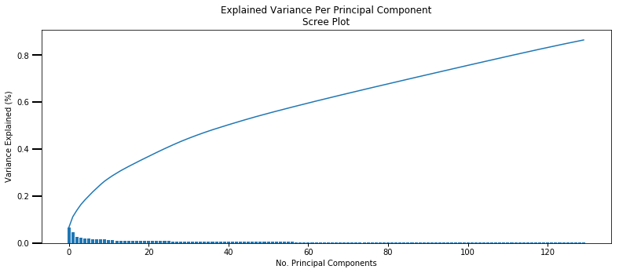

```python
ticks = np.arange(pca.n_components)
values = pca.explained_variance_ratio_

plt.figure(figsize = (13,5))
ax = plt.subplot(111)
cumvals = np.cumsum(values)
ax.bar(ticks,values)
ax.plot(ticks,cumvals)

ax.xaxis.set_tick_params(width=1)
ax.yaxis.set_tick_params(width=2,length=12)

ax.set_xlabel("No. Principal Components")
ax.set_ylabel("Variance Explained (%)")
plt.title('Explained Variance Per Principal Component\nScree Plot')
plt.show()
```

**Recap**

So above we performed PCA many times until we found a number of principal components that explains 85% variance. The scree plot above plots principal components on the x-axis, variance explained on the y-axis, bars representing amount of variance explained, and a line that cumulatively sums up the variance explained across our principal components. I've decided to go with 130 principal components because it explains a good amount of variance (again, 85%) while greatly reducing number of dimensions from 257 to 130.

### Interpreting Principal Components

Below I'll have a swing at **interpretting** what some principal components can tell us about our data.

```python
def plot_pca_dim(pca,feat_names,dim,features):
    '''
    For a given fitted PCA object, the given component, and a given number of features, this plots
    the variance that the particular component captures.
    '''
    fmt = lambda x: "{:.2f}%".format(x)
    sort_abs = lambda x: abs(x[0])

    names_to_weights = sorted(zip(pca.components_[dim],feat_names),key=sort_abs,reverse=True)
    names_to_weights = np.array(names_to_weights)

    nm_to_wt_df = pd.DataFrame(names_to_weights,columns=['var','feature'])
    nm_to_wt_df['var'] = nm_to_wt_df['var'].astype(float)

    return px.bar(nm_to_wt_df[:features],x='feature',y='var',
           color='var',color_continuous_scale=px.colors.sequential.Sunsetdark,
           labels = {'var': 'Variance (%)','feature':'Feature Names'},
           height=400,width=600)
```

```python
feat_names = azdias_1.columns.values
```

#### Component 1 (The component that explains the most variance)

*Skip ahead below all the plots for my interpretation of the PC's*

```python
plot_pca_dim(pca,feat_names,0,10)
```

[interactive chart not shown]

| Field Name | Interpretation | Pos/Neg |
| --- | --- | --- |
| MOBI_REGIO | Region: Movement Patterns | Neg |
| LP_STATUS_GROB_1.0 | Social Status | Pos |
| KBA05_ANTG1 | No. 1-2 family houses in microcell | Neg |
| PLZ8_ANTG3 | No. 6-10 family houses in region | Pos |
| PLZ8_ANTG1 | No. 1-2 family houses in region | Neg |
| FINANZ_MINIMALIST | Low Financial Interest | Neg |
| KBA05_GBZ | No. Buildings in microcell | Neg |
| HH_EINKOMMEN_SCORE | Est. Household net income | Pos |
| PLZ8_ANTG4 | No. 10+ family homes in region | Pos |
| PLZ8_BAUMAX_1.0 | Most common building type | Neg |

**Observations: Component 1**

- Positive correlation between social status, household net income, and relatively larger family homes.
- Contrast this to a negative correlation with movement patterns smaller family homes, and low financial interest.

#### Component 2

```python
plot_pca_dim(pca,feat_names,1,10)
```

[interactive chart not shown]

| Field Name | Interpretation | Pos/Neg |
| --- | --- | --- |
| ALTERSKATEGORIE_GROB | Estimated age | Pos |
| FINANZ_SPARER | Money Saver | Neg |
| FINANZ_VORSORGER | Being financially prepared | Pos |
| FINANZ_UNAUFFAELLIGER | Financially inconspicuous | Neg |
| SEMIO_REL | Personality: Religious | Neg |
| SEMIO_TRADV | Personality: Traditional-minded | Neg |
| SEMIO_PFLICHT | Personality: Dufitul | Neg |
| FINANZ_ANLEGER | Investor | Neg |
| ZABEOTYP_3 | Fair energy consumer | Pos |
| SEMIO_ERL | Personality: Event-oriented | Pos |

**Observations: Component 2**

- Positive correlation between age, being financially prepared, being a fair energy consumer, and being event-oriented.
- Negative correlations with money saving, being financially inconspicuous, religions, traditional, dutiful, and an investor.

#### Component 3

```python
plot_pca_dim(pca,feat_names,2,10)
```

[interactive chart not shown]

| Field Name | Interpretation | Pos/Neg |
| --- | --- | --- |
| ANREDE_KZ | Gender (1-M, 2-F) | Neg |
| SEMIO_VERT | Personality: Dreamful | Pos |
| SEMIO_KAEM | Personality: Combative Attitude | Neg |
| SEMIO_DOM | Personality: Dominant-minded | Neg |
| SEMIO_KRIT | Personality: Critical-minded | Neg |
| SEMIO_FAM | Personality: Family-minded | Pos |
| SEMIO_SOZ | Personality: Socially-minded | Pos |
| SEMIO_KULT | Personality: Cultural-minded | Pos |
| SEMIO_ERL | Personality: Event-oriented | Neg |
| FINANZ_ANLEGER | Investor | Neg |

**Observations: Component 3**

- Positive correlation between dreamful personality, family mindedness, social-mindedness, and cultural mindedness
- Negative correlations with gender, combative-minded, dominant-minded, critical-minded, and investing.

### Discussion: Interpretting Principal Components

```python
pca.explained_variance_ratio_[:3].sum()
```

```
0.13896057942704898
```

Cumulatively, they only explain approx. 13.9% of variance from our features, so they don't explain very much variance.

**PCA Summary Observations**

1. The first component seems **financially-driven**. It most strongly correlates social status, household income, and larger homes (positive) *against* smaller family homes and low financial interest.
2. The second component seems **personality-driven**. It shows positive correlation between age and financial preparedness, and shows negative correlation against similar, more conservative personality types (financially inconspicuous, religions, traditional, dutiful, and investing).
3. The third component also seems **personality-driven**. It shows positive correlation between dreamful, family, social, and cultural mindedness. It also shows negative correlations between gender (note value for male is lower than female = 0 vs 1), combatative, dominant, and critical mindedness.

## Clustering

### Applying Clustering to General Population

Below I will use sklearn's KMeans clustering algorithm to identify different segments of the demographics data.

One thing that's very tricky when it comes to using KMeans is the fact that you have to **choose** the number of **clusters** that the algorithm will find. This can be difficult since we don't know how many clusters exist!

So, here's what we're going to do...

1. Run KMeans on a few different values of k-clusters 1.5. Calculate Average Distance (Euclidean Distance) for each value of k-clusters
2. Analyze how much **reduced distance** we get from **each additional cluster**
3. Pick the value for k-clusters immediately before the value where we see a clear **drop** in reduction of average distance

Intuitively, this makes sense. If we have 5 clear-cut clusters in our population, adding clusters 1-5 will significantly reduce average distance between clusters. Once we add a 6th cluster, that 6th cluster will situate itself close to one of the already-defined 5 clusters, which will reduce average distance from each cluster, but not by that much.

```python
scores = []
```

First trying 3-10 clusters to see how KMeans performs.

```python
# Over a number of different cluster counts...
clusters = np.arange(3,11)
for i in clusters:
    start=time.time()
    model = KMeans(i)
    model.fit(X_pca)
    # Score is sum of squared distances to a sample's assigned centroid
    scores.append(abs(model.score(X_pca)))
    end = time.time()
    print(f'Running Score for {i} Clusters: {abs(model.score(X_pca)):.3f}')
    print(f'Time taken: {end-start:.2f} seconds.')
```

```
Running Score for 3 Clusters: 161597023.276
Time taken: 73.19 seconds.
Running Score for 4 Clusters: 158004058.975
Time taken: 85.80 seconds.
Running Score for 5 Clusters: 155379812.132
Time taken: 109.79 seconds.
Running Score for 6 Clusters: 153092423.744
Time taken: 110.24 seconds.
Running Score for 7 Clusters: 150649488.845
Time taken: 144.54 seconds.
Running Score for 8 Clusters: 148389831.896
Time taken: 148.45 seconds.
Running Score for 9 Clusters: 145435904.875
Time taken: 152.77 seconds.
Running Score for 10 Clusters: 143467713.793
Time taken: 180.77 seconds.
```

Plotting the scores below...

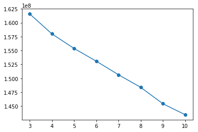

```python
plt.plot(clusters,scores,marker="o")
plt.show()
```

The scores I'm plotting are the sum of the squared distances from each point to its corresponding centroid. The trend looks linear. A possible sign of having too many clusters is diminished reduction in these distances for each additional cluster. This is known as the "elbow" method. Given the trend looks linear, I'm going to try a few more clusters below.

```python
clusters = np.arange(11,16)
for i in clusters:
    start=time.time()
    model = KMeans(i)
    model.fit(X_pca)
    # Score is sum of squared distances to a sample's assigned centroid
    scores.append(abs(model.score(X_pca)))
    end = time.time()
    print(f'Running Score for {i} Clusters: {abs(model.score(X_pca)):.3f}')
    print(f'Time taken: {end-start:.2f} seconds.')
```

```
Running Score for 11 Clusters: 142549766.933
Time taken: 190.92 seconds.
Running Score for 12 Clusters: 139869652.130
Time taken: 199.48 seconds.
Running Score for 13 Clusters: 138564471.742
Time taken: 212.23 seconds.
Running Score for 14 Clusters: 136929997.809
Time taken: 205.36 seconds.
Running Score for 15 Clusters: 136202833.209
Time taken: 214.22 seconds.
```

Replotting the scores.

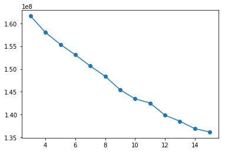

```python
plt.plot(np.arange(3,16),scores,marker="o")
plt.show()
```

```python
final_model = KMeans(13)
final_model.fit(X_pca)
```

```
KMeans(algorithm='auto', copy_x=True, init='k-means++', max_iter=300,
       n_clusters=13, n_init=10, n_jobs=None, precompute_distances='auto',
       random_state=None, tol=0.0001, verbose=0)
```

```python
gen_preds = final_model.predict(X_pca)
```

**Recap**

I fit and scored KMeans on our PCA-transformed data for n-centroids 3-15. Score is calculated as the distance between samples and their corresponding centroid. As we add centroids to the algorithm, the score will *decrease* (i.e. distance between points) *less and less*. 10 and 13 centroids seem like good candidates for our algorithm, but I chose to proceed with 13 clusters because it appears sum of squared distance was significantly reduced from 11-13 centroids.

### Applying All Steps to the Customer Data

Below I'm cleaning, scaling, PCA-ing, and clustering our customer data using all the objects and steps we used on the demographics data.

```python
# Load in the customer demographics data.
customers = pd.read_csv('Udacity_CUSTOMERS_Subset.csv',';')
```

```python
customers.head()
```

|  | AGER_TYP | ALTERSKATEGORIE_GROB | ANREDE_KZ | CJT_GESAMTTYP | FINANZ_MINIMALIST | FINANZ_SPARER | FINANZ_VORSORGER | FINANZ_ANLEGER | FINANZ_UNAUFFAELLIGER | FINANZ_HAUSBAUER | ... | PLZ8_ANTG1 | PLZ8_ANTG2 | PLZ8_ANTG3 | PLZ8_ANTG4 | PLZ8_BAUMAX | PLZ8_HHZ | PLZ8_GBZ | ARBEIT | ORTSGR_KLS9 | RELAT_AB |
| --- | --- | --- | --- | --- | --- | --- | --- | --- | --- | --- | --- | --- | --- | --- | --- | --- | --- | --- | --- | --- | --- |
| 0 | 2 | 4 | 1 | 5.0 | 5 | 1 | 5 | 1 | 2 | 2 | ... | 3.0 | 3.0 | 1.0 | 0.0 | 1.0 | 5.0 | 5.0 | 1.0 | 2.0 | 1.0 |
| 1 | -1 | 4 | 1 | NaN | 5 | 1 | 5 | 1 | 3 | 2 | ... | NaN | NaN | NaN | NaN | NaN | NaN | NaN | NaN | NaN | NaN |
| 2 | -1 | 4 | 2 | 2.0 | 5 | 1 | 5 | 1 | 4 | 4 | ... | 2.0 | 3.0 | 3.0 | 1.0 | 3.0 | 3.0 | 2.0 | 3.0 | 5.0 | 3.0 |
| 3 | 1 | 4 | 1 | 2.0 | 5 | 1 | 5 | 2 | 1 | 2 | ... | 3.0 | 2.0 | 1.0 | 0.0 | 1.0 | 3.0 | 4.0 | 1.0 | 3.0 | 1.0 |
| 4 | -1 | 3 | 1 | 6.0 | 3 | 1 | 4 | 4 | 5 | 2 | ... | 2.0 | 4.0 | 2.0 | 1.0 | 2.0 | 3.0 | 3.0 | 3.0 | 5.0 | 1.0 |

5 rows × 85 columns

**Cleaning**

```python
cleaned_cust = clean_data(customers)
```

```python
cleaned_cust.shape
```

```
(141725, 256)
```

The imputer and scaler aren't going to work because "GEBAEUDETYP_5.0" isn't in our `cleaned_cust` DataFrame. This wasn't created because the "GEBAEUDETYP" column didn't have any values of `5` in our customer set since we one-hot encoded it using `pd.get_dummies` instead of `OneHotEncoder`. Adding in a column of only zeros for this missing column is an equivalent operation to not having any values of `5` for this feature.

```python
for i in azdias_1.columns:
    if i not in cleaned_cust.columns:
        print(i)
```

```
GEBAEUDETYP_5.0
```

```python
GEBAEUDETYP_5 = pd.Series(np.zeros(141725))
cleaned_cust['GEBAEUDETYP_5.0'] = GEBAEUDETYP_5
```

```python
# Reordering columns to align with original DataFrame
cols = azdias_1.columns.tolist()
cleaned_cust = cleaned_cust[cols]
```

```python
cleaned_cust.shape
```

```
(141725, 257)
```

**Imputing & Standardization**

```python
imputed = med_imp.transform(cleaned_cust)
standardized = scaler.transform(imputed)
```

```python
standardized.shape
```

```
(141725, 257)
```

**PCA**

```python
X_pca_cust = pca.transform(standardized)
```

```python
X_pca_cust.shape
```

```
(141725, 130)
```

**Clustering**

```python
preds = final_model.predict(X_pca_cust)
```

### Comparing Customer Data to Demographics Data

Now that we have **both** our demographics data and our customer data clustered let's compare them!

```python
df_preds_cust = pd.DataFrame(preds,columns=['cust_preds'])
df_preds_gen =  pd.DataFrame(gen_preds,columns=['gen_preds'])
```

```python
prop_cust = df_preds_cust['cust_preds'].value_counts().sort_index()/ \
                sum(df_preds_cust['cust_preds'].value_counts())
prop_gen = df_preds_gen['gen_preds'].value_counts().sort_index()/ \
                sum(df_preds_gen['gen_preds'].value_counts())
```

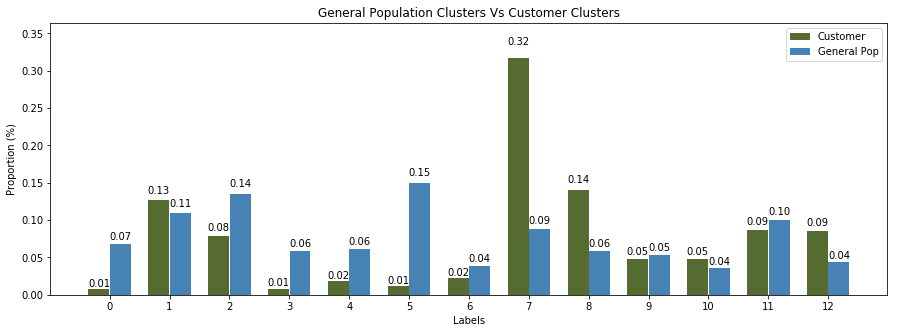

```python
fig,ax = plt.subplots(figsize=(15,5))
width = 0.35

cust = ax.bar(prop_cust.index-.51*width, prop_cust, width, color='darkolivegreen')
gen = ax.bar(prop_gen.index+.51*width, prop_gen, width, color='steelblue')


ax.set_ylabel('Proportion (%)')
ax.set_xlabel('Labels')
ax.set_title('General Population Clusters Vs Customer Clusters')
ax.set_xticks(prop_cust.index)
ax.set_ylim(top=max(prop_cust.append(prop_gen))*1.15)
ax.legend(('Customer','General Pop'))

def autolabel(rects):
    """
    Attach a text label above each bar displaying its height
    """
    for rect in rects:
        height = rect.get_height()
        ax.text(rect.get_x() + rect.get_width()/2., 1.05*height,
                '%.2f' % float(height),
                ha='center', va='bottom')

autolabel(cust)
autolabel(gen)
```

- General Pop
  - 7x label 0
  - 6x label 3
  - 15x label 5
- Customer
  - 2x label 8
  - 3x label 7

So we can see that some clusters are **over-represented** in our customer data and some are **under-represented** in our customer data. Let's take a look at what characteristics describe these clusters to help us understand **who our customers are**.